# COMPSCIX 415.2 Homework 6

Gwen Rino

March 7, 2018

```r
library(tidyverse)
library(mosaicData)
library(forcats)
```

## EXERCISE ONE

1. The Whickham data frame has three variables: `outcome` (Alive/Dead) is survival status after 20 years, `smoker` (No/Yes) is smoking status at baseline, and `age` (in years) is age at the time of the first survey.
2. The Whickham data frame has 1314 observations. Each observation is survey results about one woman from Whickham, England.
3. The visualization below shows that a higher proportion of smokers than non-smokers are alive after 20 years. This is a surprising outcome given all we know about the effect of smoking on longevity.

```r
Whickham %>% count(smoker, outcome)
```

```
## # A tibble: 4 x 3
##   smoker outcome     n
##   <fct>  <fct>   <int>
## 1 No     Alive     502
## 2 No     Dead      230
## 3 Yes    Alive     443
## 4 Yes    Dead      139
```

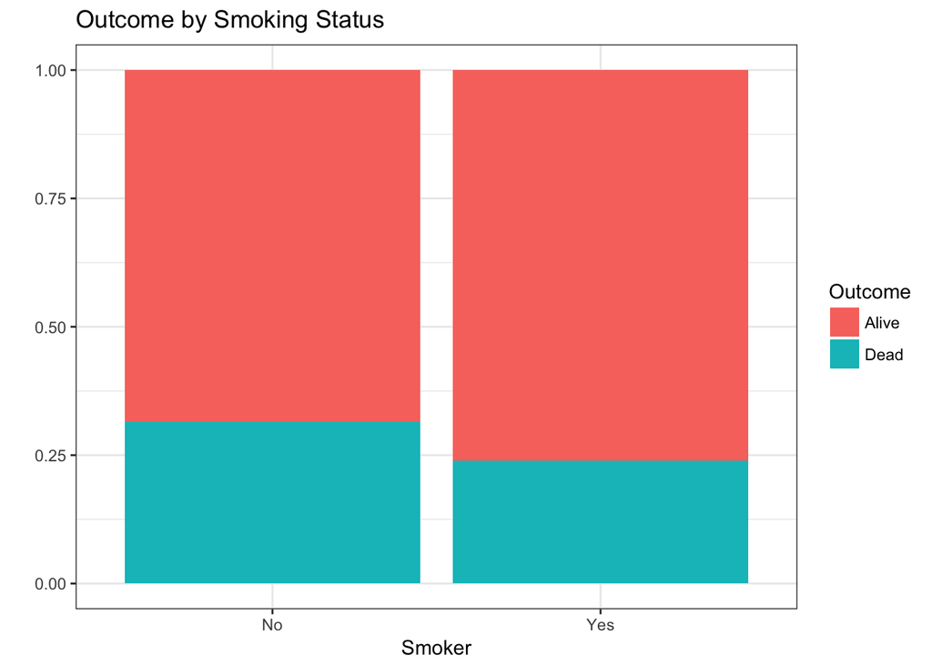

```r
Whickham %>% count(smoker, outcome) %>%
  ggplot() + geom_bar(aes(x = smoker, y = n, fill = outcome),
                      stat = "identity", position = "fill") +
  labs(x = "Smoker", y = "", fill = "Outcome", title = "Outcome by Smoking Status") + theme_bw()
```

4. The visualization below shows that when age is taken into account, a higher proportion of non-smokers than smokers are alive after 20 years. This makes sense: it reflects differences in the number of people in the three age groups, and the different smoking rates and different death rates for people of different ages (see second and third visualizations). It is an example of Simpson’s paradox that groups of data may show one particular trend, but this trend is reversed when the groups are combined together.

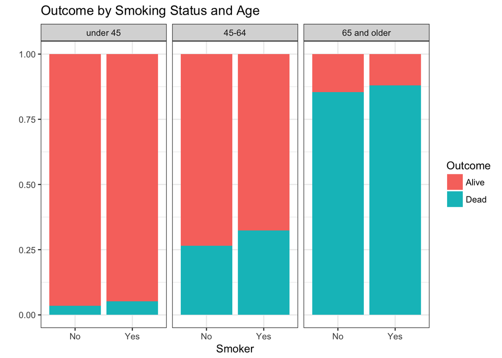

```r
# Create vector of levels for new variable
age_cat <- case_when(Whickham$age <= 44 ~ "under 45",
                     Whickham$age > 44 & Whickham$age <= 64 ~ "45-64",
                     Whickham$age > 64 ~ "65 and older")
# Recode vector as ordered factor
age_cat <- fct_relevel(age_cat, "under 45", "45-64", "65 and older")
# Add vector to dataframe as new variable
Whickham_2 <- Whickham %>% mutate(age_bin = age_cat)

# Visualization of outcome by smoking status and age
Whickham_2 %>% count(smoker, outcome, age_bin) %>%
  ggplot() + geom_bar(aes(x = smoker, y = n, fill = outcome),
                      stat = "identity", position = "fill") +
  facet_grid(~ age_bin) +
  labs(x = "Smoker", y = "", fill = "Outcome", title = "Outcome by Smoking Status and Age") + theme_bw()
```

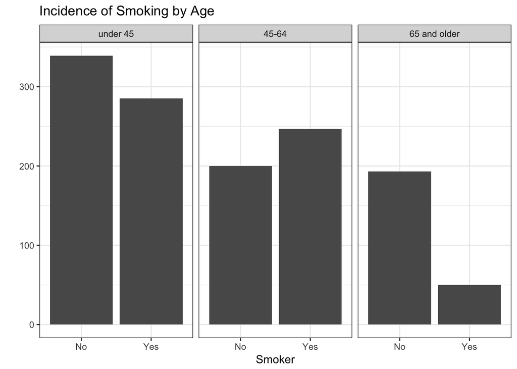

```r
# Visualization of smoking status by age
Whickham_2 %>% count(smoker, age_bin) %>%
  ggplot() + geom_bar(aes(x = smoker, y = n), stat = "identity") +
  facet_grid(~ age_bin) +
  labs(x = "Smoker", y = "", title = "Incidence of Smoking by Age") +
  theme_bw()
```

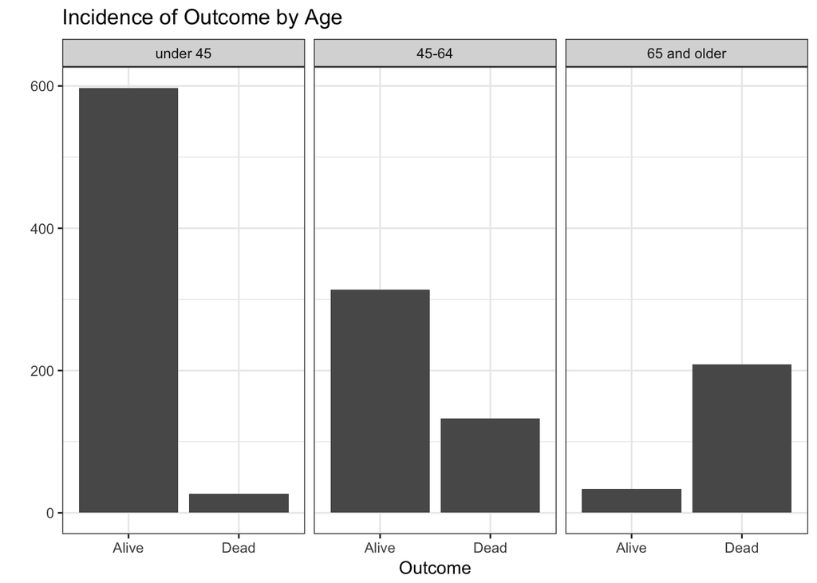

```r
# Visualization of outcome by age
Whickham_2 %>% count(outcome, age_bin) %>%
  ggplot() + geom_bar(aes(x = outcome, y = n), stat = "identity") +
  facet_grid(~ age_bin) +
  labs(x = "Outcome", y = "", title = "Incidence of Outcome by Age") +
  theme_bw()
```

## EXERCISE TWO

1. Below is a random sample of size n = 10000 of a Gamma(1,2) distribution and a histogram of the sample distribution.

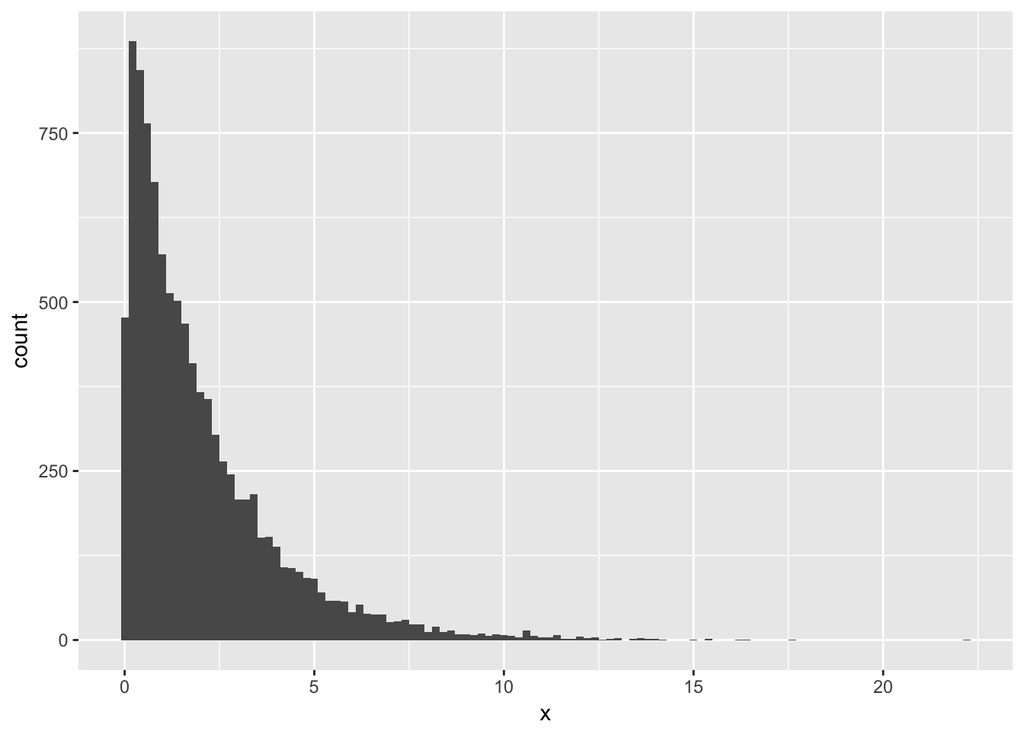

```r
n <- 10000
gamma_samp <- tibble(x = rgamma(n, shape = 1, scale = 2))
ggplot(gamma_samp, aes(x=x)) + geom_histogram(binwidth = .2)
```

2. Mean and standard deviation of the sample are below:

```r
gamma_samp %>%
  summarize(mean_samp = mean(x), sd_samp = sd(x))
```

```
## # A tibble: 1 x 2
##   mean_samp sd_samp
##       <dbl>   <dbl>
## 1      2.01    2.04
```

3. Do the whole thing again with a sample size n=30.

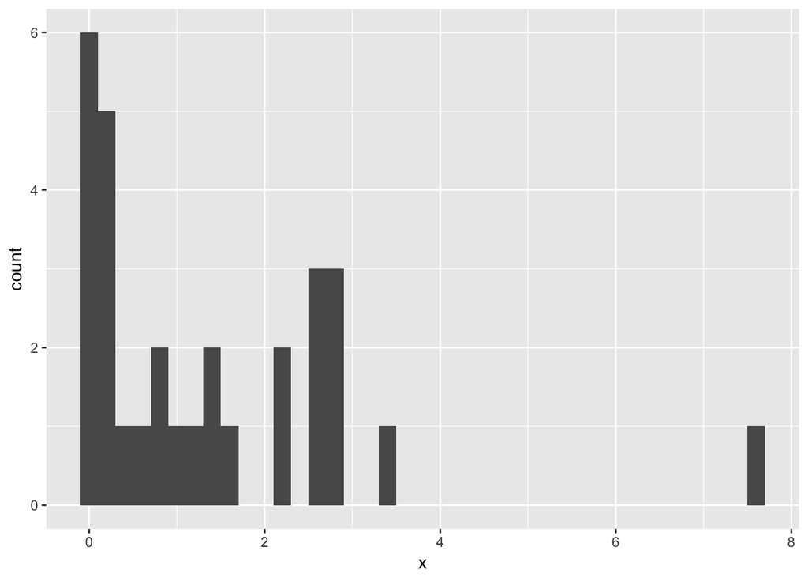

```r
n <- 30
gamma_samp_2 <- tibble(x = rgamma(n, shape = 1, scale = 2))
ggplot(gamma_samp_2, aes(x=x)) + geom_histogram(binwidth = .2)
```

```r
gamma_samp_2 %>%
  summarize(mean_samp = mean(x), sd_samp = sd(x))
```

```
## # A tibble: 1 x 2
##   mean_samp sd_samp
##       <dbl>   <dbl>
## 1      1.41    1.60
```

4. Create a vector of the means of 10,000 samples (n=30) of the Gamma(1,2) distribution. Thank your teacher for basically doing all the work.

```r
# Create a vector with 10000 NAs
mean_samp <- rep(NA, 10000)

# Use for loop to generate vector of means
for(i in 1:10000) {
  g_samp <- rgamma(30, shape = 1, scale = 2)
  mean_samp[i] <- mean(g_samp)
}
# Convert vector to a tibble
mean_samp <- tibble(mean_samp)
```

5. Make a histogram of your collection of means from above.

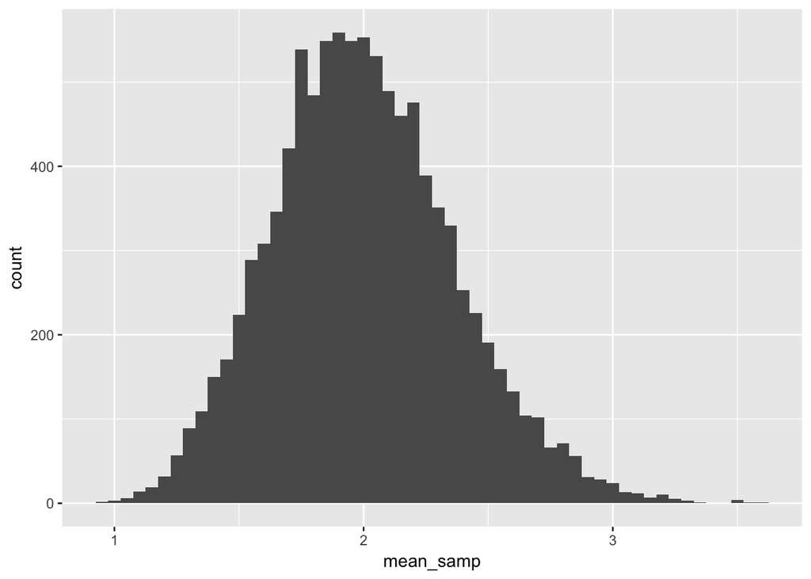

```r
ggplot(mean_samp, aes(x=mean_samp)) + geom_histogram(binwidth = .05)
```

6.Calculate the mean and standard deviation of all of your sample means.

```r
mean_samp %>%
  summarize(mean = mean(mean_samp), sd = sd(mean_samp))
```

```
## # A tibble: 1 x 2
##    mean    sd
##   <dbl> <dbl>
## 1  2.00 0.365
```

7. Without thinking much about it, I anticipated that both the mean and the standard deviation of the 10,000 means would be close to 2 (similar to the mean and standard deviation of one sample), so I was surprised for a moment that the standard deviation of the 10,000 means was about 0.37. But of course this makes sense! The means of the samples are measures of center of the samples, so they don’t vary as widely as the samples do, so the standard deviation of the means is less than the standard deviation of a sample.
8. Below are a histogram and a calculation of mean and standard deviation for the means of 300 samples of the Gamma(1,2) distribution. While the histogram is a pretty rough approximation of a normal curve, the mean and standard deviation match up quite well with the Central Limit Theorem, which predicts that the mean should be close to 2 and the standard deviation should be about 0.365.

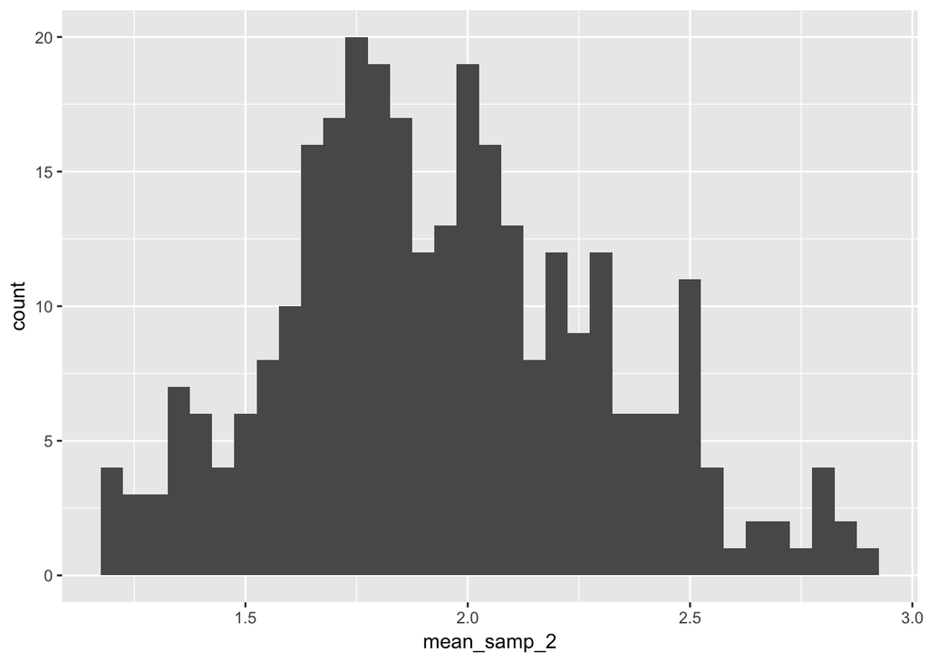

```r
# Create a vector with 300 NAs
mean_samp_2 <- rep(NA, 300)

# Use for loop to generate vector of means
for(i in 1:300) {
  g_samp <- rgamma(30, shape = 1, scale = 2)
  mean_samp_2[i] <- mean(g_samp)
}
# Convert vector to a tibble
mean_samp_2 <- tibble(mean_samp_2)

# Histogram
ggplot(mean_samp_2, aes(x=mean_samp_2)) + geom_histogram(binwidth = .05)
```

```r
# Mean and standard deviation
mean_samp_2 %>%
  summarize(mean = mean(mean_samp_2), sd = sd(mean_samp_2))
```

```
## # A tibble: 1 x 2
##    mean    sd
##   <dbl> <dbl>
## 1  1.95 0.360
```